# Project 1. Mercedes-Benz Greener Manufacturing

### DESCRIPTION

Reduce the time a Mercedes-Benz spends on the test bench.

#### Problem Statement Scenario:

Since the first automobile, the Benz Patent Motor Car in 1886, Mercedes-Benz has stood for important automotive innovations. These include the passenger safety cell with a crumple zone, the airbag, and intelligent assistance systems. Mercedes-Benz applies for nearly 2000 patents per year, making the brand the European leader among premium carmakers. Mercedes-Benz is the leader in the premium car industry. With a huge selection of features and options, customers can choose the customized Mercedes-Benz of their dreams.

To ensure the safety and reliability of every unique car configuration before they hit the road, the company’s engineers have developed a robust testing system. As one of the world’s biggest manufacturers of premium cars, safety and efficiency are paramount on Mercedes-Benz’s production lines. However, optimizing the speed of their testing system for many possible feature combinations is complex and time-consuming without a powerful algorithmic approach.

You are required to reduce the time that cars spend on the test bench. Others will work with a dataset representing different permutations of features in a Mercedes-Benz car to predict the time it takes to pass testing. Optimal algorithms will contribute to faster testing, resulting in lower carbon dioxide emissions without reducing Mercedes-Benz’s standards.

#### Following actions should be performed:

1) If for any column(s), the variance is equal to zero, then you need to remove those variable(s).

2) Check for null and unique values for test and train sets.

3) Apply label encoder.

4) Perform dimensionality reduction.

5) Predict your test_df values using XGBoost.

#### Process Description:

Firstly, the train dataset has the target variable, thus we build the model out of it and evaluate our model by splitting the train dataset into train and test data. Finally, our objective is to find out the target variable for test dataset which is absent in that dataset. During the course of this project, it has been inferred that the data pre-processing steps are crutial to preserve model accuracy.

# PART A: Training and Testing the Train data

```python
# Installing package for MCA (Dimensionality Reduction)
!pip install prince
```

```python
# Importing Libraries for EDA
import pandas as pd
import numpy as np
```

```python
# Importing the train dataset called "train.csv"
df = pd.read_csv("train.csv")
```

```python
df.head()
```

|  | ID | y | X0 | X1 | X2 | X3 | X4 | X5 | X6 | X8 | ... | X375 | X376 | X377 | X378 | X379 | X380 | X382 | X383 | X384 | X385 |
| --- | --- | --- | --- | --- | --- | --- | --- | --- | --- | --- | --- | --- | --- | --- | --- | --- | --- | --- | --- | --- | --- |
| 0 | 0 | 130.81 | k | v | at | a | d | u | j | o | ... | 0 | 0 | 1 | 0 | 0 | 0 | 0 | 0 | 0 | 0 |
| 1 | 6 | 88.53 | k | t | av | e | d | y | l | o | ... | 1 | 0 | 0 | 0 | 0 | 0 | 0 | 0 | 0 | 0 |
| 2 | 7 | 76.26 | az | w | n | c | d | x | j | x | ... | 0 | 0 | 0 | 0 | 0 | 0 | 1 | 0 | 0 | 0 |
| 3 | 9 | 80.62 | az | t | n | f | d | x | l | e | ... | 0 | 0 | 0 | 0 | 0 | 0 | 0 | 0 | 0 | 0 |
| 4 | 13 | 78.02 | az | v | n | f | d | h | d | n | ... | 0 | 0 | 0 | 0 | 0 | 0 | 0 | 0 | 0 | 0 |

5 rows × 378 columns

```python
# Dropping column "ID" which is irrelevant for building the model
df = df.drop("ID",axis=1)
```

```python
df.head()
```

|  | y | X0 | X1 | X2 | X3 | X4 | X5 | X6 | X8 | X10 | ... | X375 | X376 | X377 | X378 | X379 | X380 | X382 | X383 | X384 | X385 |
| --- | --- | --- | --- | --- | --- | --- | --- | --- | --- | --- | --- | --- | --- | --- | --- | --- | --- | --- | --- | --- | --- |
| 0 | 130.81 | k | v | at | a | d | u | j | o | 0 | ... | 0 | 0 | 1 | 0 | 0 | 0 | 0 | 0 | 0 | 0 |
| 1 | 88.53 | k | t | av | e | d | y | l | o | 0 | ... | 1 | 0 | 0 | 0 | 0 | 0 | 0 | 0 | 0 | 0 |
| 2 | 76.26 | az | w | n | c | d | x | j | x | 0 | ... | 0 | 0 | 0 | 0 | 0 | 0 | 1 | 0 | 0 | 0 |
| 3 | 80.62 | az | t | n | f | d | x | l | e | 0 | ... | 0 | 0 | 0 | 0 | 0 | 0 | 0 | 0 | 0 | 0 |
| 4 | 78.02 | az | v | n | f | d | h | d | n | 0 | ... | 0 | 0 | 0 | 0 | 0 | 0 | 0 | 0 | 0 | 0 |

5 rows × 377 columns

#### Variance = 0 Interpretation

A variance value of zero, though, indicates that all values within a set of numbers are identical. Every variance that isn't zero is a positive number. A variance cannot be negative. That's because it's mathematically impossible since you can't have a negative value resulting from a square.

```python
# Taking out the variables which have variance > 0 and are used for creating the model
df_input = df.loc[:,df.nunique()!=1]
```

```python
df_input.head()
```

|  | y | X0 | X1 | X2 | X3 | X4 | X5 | X6 | X8 | X10 | ... | X375 | X376 | X377 | X378 | X379 | X380 | X382 | X383 | X384 | X385 |
| --- | --- | --- | --- | --- | --- | --- | --- | --- | --- | --- | --- | --- | --- | --- | --- | --- | --- | --- | --- | --- | --- |
| 0 | 130.81 | k | v | at | a | d | u | j | o | 0 | ... | 0 | 0 | 1 | 0 | 0 | 0 | 0 | 0 | 0 | 0 |
| 1 | 88.53 | k | t | av | e | d | y | l | o | 0 | ... | 1 | 0 | 0 | 0 | 0 | 0 | 0 | 0 | 0 | 0 |
| 2 | 76.26 | az | w | n | c | d | x | j | x | 0 | ... | 0 | 0 | 0 | 0 | 0 | 0 | 1 | 0 | 0 | 0 |
| 3 | 80.62 | az | t | n | f | d | x | l | e | 0 | ... | 0 | 0 | 0 | 0 | 0 | 0 | 0 | 0 | 0 | 0 |
| 4 | 78.02 | az | v | n | f | d | h | d | n | 0 | ... | 0 | 0 | 0 | 0 | 0 | 0 | 0 | 0 | 0 | 0 |

5 rows × 365 columns

```python
df_input.shape
```

```
(4209, 365)
```

```python
# Taking out the variables which have variance = 0 and are left out
df_output = df.loc[:,df.nunique()==1]
```

```python
df_output.head()
```

|  | X11 | X93 | X107 | X233 | X235 | X268 | X289 | X290 | X293 | X297 | X330 | X347 |
| --- | --- | --- | --- | --- | --- | --- | --- | --- | --- | --- | --- | --- |
| 0 | 0 | 0 | 0 | 0 | 0 | 0 | 0 | 0 | 0 | 0 | 0 | 0 |
| 1 | 0 | 0 | 0 | 0 | 0 | 0 | 0 | 0 | 0 | 0 | 0 | 0 |
| 2 | 0 | 0 | 0 | 0 | 0 | 0 | 0 | 0 | 0 | 0 | 0 | 0 |
| 3 | 0 | 0 | 0 | 0 | 0 | 0 | 0 | 0 | 0 | 0 | 0 | 0 |
| 4 | 0 | 0 | 0 | 0 | 0 | 0 | 0 | 0 | 0 | 0 | 0 | 0 |

```python
# Checking out the null values in our dataset
df_input.isnull().sum()/len(df)*100
```

```
y       0.0
X0      0.0
X1      0.0
X2      0.0
X3      0.0
       ...
X380    0.0
X382    0.0
X383    0.0
X384    0.0
X385    0.0
Length: 365, dtype: float64
```

```python
# Checking out the unique values in our dataset
df_input.nunique()
```

```
y       2545
X0        47
X1        27
X2        44
X3         7
        ...
X380       2
X382       2
X383       2
X384       2
X385       2
Length: 365, dtype: int64
```

```python
# Separating the dataset into independent and dependent variables
X_obj = df_input.drop("y",axis=1)
y = df["y"]
```

```python
X_obj.head()
```

|  | X0 | X1 | X2 | X3 | X4 | X5 | X6 | X8 | X10 | X12 | ... | X375 | X376 | X377 | X378 | X379 | X380 | X382 | X383 | X384 | X385 |
| --- | --- | --- | --- | --- | --- | --- | --- | --- | --- | --- | --- | --- | --- | --- | --- | --- | --- | --- | --- | --- | --- |
| 0 | k | v | at | a | d | u | j | o | 0 | 0 | ... | 0 | 0 | 1 | 0 | 0 | 0 | 0 | 0 | 0 | 0 |
| 1 | k | t | av | e | d | y | l | o | 0 | 0 | ... | 1 | 0 | 0 | 0 | 0 | 0 | 0 | 0 | 0 | 0 |
| 2 | az | w | n | c | d | x | j | x | 0 | 0 | ... | 0 | 0 | 0 | 0 | 0 | 0 | 1 | 0 | 0 | 0 |
| 3 | az | t | n | f | d | x | l | e | 0 | 0 | ... | 0 | 0 | 0 | 0 | 0 | 0 | 0 | 0 | 0 | 0 |
| 4 | az | v | n | f | d | h | d | n | 0 | 0 | ... | 0 | 0 | 0 | 0 | 0 | 0 | 0 | 0 | 0 | 0 |

5 rows × 364 columns

```python
y.head()
```

```
0    130.81
1     88.53
2     76.26
3     80.62
4     78.02
Name: y, dtype: float64
```

```python
# Checking out the data type of the features
X_obj.dtypes
```

```
X0      object
X1      object
X2      object
X3      object
X4      object
         ...
X380     int64
X382     int64
X383     int64
X384     int64
X385     int64
Length: 364, dtype: object
```

```python
# Importing prince library for MCA
import prince
```

#### Multiple Correspondance Analysis (MCA)

In statistics, multiple correspondence analysis (MCA) is a data analysis technique for nominal categorical data, used to detect and represent underlying structures in a data set. It does this by representing data as points in a low-dimensional Euclidean space. The procedure thus appears to be the counterpart of principal component analysis for categorical data. MCA can be viewed as an extension of simple correspondence analysis (CA) in that it is applicable to a large set of categorical variables.

```python
# Initializing the MCA object to fit the data and will display MCA plot coordinates
mca = prince.MCA(n_components=2, n_iter=3, copy=True, check_input=True, engine='auto', random_state=42)
X_mca = mca.fit(X_obj)
```

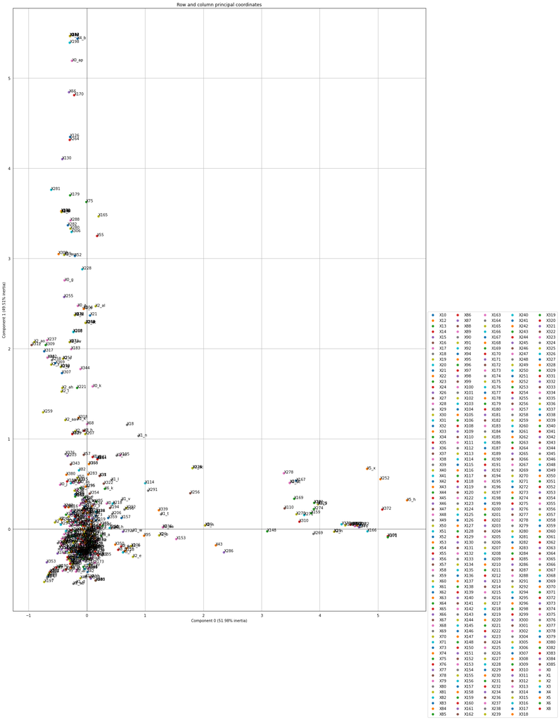

```python
# Viewing the MCA plot using the first two coordinates
ax = X_mca.plot_coordinates(X=X_obj, ax=None, figsize=(20, 30), show_row_points=False, row_points_size=0, show_row_labels=False, show_column_points=True, column_points_size=30, show_column_labels=True, legend_n_cols=1).legend(bbox_to_anchor=(1, 0.5), ncol=5)
```

```python
# Importing the label Encoder package for transforming the alphabetical into numerical variables
from sklearn.preprocessing import LabelEncoder
```

#### Label Encoder

It a very efficient tool for encoding the levels of categorical features into numeric values. LabelEncoder encode labels with a value between 0 and n_classes-1 where n is the number of distinct labels. If a label repeats it assigns the same value to as assigned earlier.

```python
# Creating a Label Encoder object
le = LabelEncoder()
```

```python
# Transforming the alphabetical variables to numerical by fitting the data in the Label Encoder object
X_obj["X0"] = le.fit_transform(X_obj["X0"])
X_obj["X1"] = le.fit_transform(X_obj["X1"])
X_obj["X2"] = le.fit_transform(X_obj["X2"])
X_obj["X3"] = le.fit_transform(X_obj["X3"])
X_obj["X4"] = le.fit_transform(X_obj["X4"])
X_obj["X5"] = le.fit_transform(X_obj["X5"])
X_obj["X6"] = le.fit_transform(X_obj["X6"])
X_obj["X8"] = le.fit_transform(X_obj["X8"])
```

```python
X_obj.head()
```

|  | X0 | X1 | X2 | X3 | X4 | X5 | X6 | X8 | X10 | X12 | ... | X375 | X376 | X377 | X378 | X379 | X380 | X382 | X383 | X384 | X385 |
| --- | --- | --- | --- | --- | --- | --- | --- | --- | --- | --- | --- | --- | --- | --- | --- | --- | --- | --- | --- | --- | --- |
| 0 | 32 | 23 | 17 | 0 | 3 | 24 | 9 | 14 | 0 | 0 | ... | 0 | 0 | 1 | 0 | 0 | 0 | 0 | 0 | 0 | 0 |
| 1 | 32 | 21 | 19 | 4 | 3 | 28 | 11 | 14 | 0 | 0 | ... | 1 | 0 | 0 | 0 | 0 | 0 | 0 | 0 | 0 | 0 |
| 2 | 20 | 24 | 34 | 2 | 3 | 27 | 9 | 23 | 0 | 0 | ... | 0 | 0 | 0 | 0 | 0 | 0 | 1 | 0 | 0 | 0 |
| 3 | 20 | 21 | 34 | 5 | 3 | 27 | 11 | 4 | 0 | 0 | ... | 0 | 0 | 0 | 0 | 0 | 0 | 0 | 0 | 0 | 0 |
| 4 | 20 | 23 | 34 | 5 | 3 | 12 | 3 | 13 | 0 | 0 | ... | 0 | 0 | 0 | 0 | 0 | 0 | 0 | 0 | 0 | 0 |

5 rows × 364 columns

```python
# Importing the MinMaXScaler
from sklearn.preprocessing import MinMaxScaler
```

#### Scaling

```python
# Initiating the MinMaxScaler object
mn = MinMaxScaler()
```

```python
# Scaling the first 7 variables to return their values in the range of (0,1)
X_obj["X0"] = mn.fit_transform(X_obj[["X0"]])
X_obj["X1"] = mn.fit_transform(X_obj[["X1"]])
X_obj["X2"] = mn.fit_transform(X_obj[["X2"]])
X_obj["X3"] = mn.fit_transform(X_obj[["X3"]])
X_obj["X5"] = mn.fit_transform(X_obj[["X5"]])
X_obj["X6"] = mn.fit_transform(X_obj[["X6"]])
X_obj["X8"] = mn.fit_transform(X_obj[["X8"]])
```

```python
X_obj.head()
```

|  | X0 | X1 | X2 | X3 | X4 | X5 | X6 | X8 | X10 | X12 | ... | X375 | X376 | X377 | X378 | X379 | X380 | X382 | X383 | X384 | X385 |
| --- | --- | --- | --- | --- | --- | --- | --- | --- | --- | --- | --- | --- | --- | --- | --- | --- | --- | --- | --- | --- | --- |
| 0 | 0.695652 | 0.884615 | 0.395349 | 0.000000 | 3 | 0.857143 | 0.818182 | 0.583333 | 0 | 0 | ... | 0 | 0 | 1 | 0 | 0 | 0 | 0 | 0 | 0 | 0 |
| 1 | 0.695652 | 0.807692 | 0.441860 | 0.666667 | 3 | 1.000000 | 1.000000 | 0.583333 | 0 | 0 | ... | 1 | 0 | 0 | 0 | 0 | 0 | 0 | 0 | 0 | 0 |
| 2 | 0.434783 | 0.923077 | 0.790698 | 0.333333 | 3 | 0.964286 | 0.818182 | 0.958333 | 0 | 0 | ... | 0 | 0 | 0 | 0 | 0 | 0 | 1 | 0 | 0 | 0 |
| 3 | 0.434783 | 0.807692 | 0.790698 | 0.833333 | 3 | 0.964286 | 1.000000 | 0.166667 | 0 | 0 | ... | 0 | 0 | 0 | 0 | 0 | 0 | 0 | 0 | 0 | 0 |
| 4 | 0.434783 | 0.884615 | 0.790698 | 0.833333 | 3 | 0.428571 | 0.272727 | 0.541667 | 0 | 0 | ... | 0 | 0 | 0 | 0 | 0 | 0 | 0 | 0 | 0 | 0 |

5 rows × 364 columns

```python
# Adding the target variable to the DataFrame for row deletion
X_obj["y"] = df["y"]
```

```python
X_obj.head()
```

|  | X0 | X1 | X2 | X3 | X4 | X5 | X6 | X8 | X10 | X12 | ... | X376 | X377 | X378 | X379 | X380 | X382 | X383 | X384 | X385 | y |
| --- | --- | --- | --- | --- | --- | --- | --- | --- | --- | --- | --- | --- | --- | --- | --- | --- | --- | --- | --- | --- | --- |
| 0 | 0.695652 | 0.884615 | 0.395349 | 0.000000 | 3 | 0.857143 | 0.818182 | 0.583333 | 0 | 0 | ... | 0 | 1 | 0 | 0 | 0 | 0 | 0 | 0 | 0 | 130.81 |
| 1 | 0.695652 | 0.807692 | 0.441860 | 0.666667 | 3 | 1.000000 | 1.000000 | 0.583333 | 0 | 0 | ... | 0 | 0 | 0 | 0 | 0 | 0 | 0 | 0 | 0 | 88.53 |
| 2 | 0.434783 | 0.923077 | 0.790698 | 0.333333 | 3 | 0.964286 | 0.818182 | 0.958333 | 0 | 0 | ... | 0 | 0 | 0 | 0 | 0 | 1 | 0 | 0 | 0 | 76.26 |
| 3 | 0.434783 | 0.807692 | 0.790698 | 0.833333 | 3 | 0.964286 | 1.000000 | 0.166667 | 0 | 0 | ... | 0 | 0 | 0 | 0 | 0 | 0 | 0 | 0 | 0 | 80.62 |
| 4 | 0.434783 | 0.884615 | 0.790698 | 0.833333 | 3 | 0.428571 | 0.272727 | 0.541667 | 0 | 0 | ... | 0 | 0 | 0 | 0 | 0 | 0 | 0 | 0 | 0 | 78.02 |

5 rows × 365 columns

```python
X_obj.shape
```

```
(4209, 365)
```

```python
# Importing the vizualisaton libraries
import seaborn as sns
import matplotlib.pyplot as plt
```

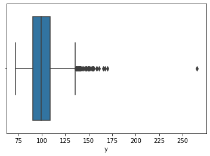

```python
# Vizualizing the box plot for the target variable to check for outliers
sns.boxplot(X_obj["y"])
plt.show()
```

#### Outliers Removal

When modeling, it is important to clean the data sample to ensure that the observations best represent the problem. Sometimes a dataset can contain extreme values that are outside the range of what is expected and unlike the other data. These are called outliers and often machine learning modeling and model skill in general can be improved by understanding and even removing these outlier values.

```python
# Creating a new variable "temp" in which null values are left out
temp = X_obj[~(X_obj["y"].isnull())]
```

```python
temp
```

|  | X0 | X1 | X2 | X3 | X4 | X5 | X6 | X8 | X10 | X12 | ... | X376 | X377 | X378 | X379 | X380 | X382 | X383 | X384 | X385 | y |
| --- | --- | --- | --- | --- | --- | --- | --- | --- | --- | --- | --- | --- | --- | --- | --- | --- | --- | --- | --- | --- | --- |
| 0 | 0.695652 | 0.884615 | 0.395349 | 0.000000 | 3 | 0.857143 | 0.818182 | 0.583333 | 0 | 0 | ... | 0 | 1 | 0 | 0 | 0 | 0 | 0 | 0 | 0 | 130.81 |
| 1 | 0.695652 | 0.807692 | 0.441860 | 0.666667 | 3 | 1.000000 | 1.000000 | 0.583333 | 0 | 0 | ... | 0 | 0 | 0 | 0 | 0 | 0 | 0 | 0 | 0 | 88.53 |
| 2 | 0.434783 | 0.923077 | 0.790698 | 0.333333 | 3 | 0.964286 | 0.818182 | 0.958333 | 0 | 0 | ... | 0 | 0 | 0 | 0 | 0 | 1 | 0 | 0 | 0 | 76.26 |
| 3 | 0.434783 | 0.807692 | 0.790698 | 0.833333 | 3 | 0.964286 | 1.000000 | 0.166667 | 0 | 0 | ... | 0 | 0 | 0 | 0 | 0 | 0 | 0 | 0 | 0 | 80.62 |
| 4 | 0.434783 | 0.884615 | 0.790698 | 0.833333 | 3 | 0.428571 | 0.272727 | 0.541667 | 0 | 0 | ... | 0 | 0 | 0 | 0 | 0 | 0 | 0 | 0 | 0 | 78.02 |
| ... | ... | ... | ... | ... | ... | ... | ... | ... | ... | ... | ... | ... | ... | ... | ... | ... | ... | ... | ... | ... | ... |
| 4204 | 0.173913 | 0.769231 | 0.372093 | 0.333333 | 3 | 0.000000 | 0.272727 | 0.666667 | 0 | 0 | ... | 0 | 0 | 0 | 0 | 0 | 0 | 0 | 0 | 0 | 107.39 |
| 4205 | 0.673913 | 0.615385 | 0.930233 | 0.500000 | 3 | 0.000000 | 0.636364 | 0.291667 | 0 | 0 | ... | 1 | 0 | 0 | 0 | 0 | 0 | 0 | 0 | 0 | 108.77 |
| 4206 | 0.173913 | 0.884615 | 0.883721 | 0.000000 | 3 | 0.000000 | 0.545455 | 0.166667 | 0 | 1 | ... | 0 | 1 | 0 | 0 | 0 | 0 | 0 | 0 | 0 | 109.22 |
| 4207 | 0.195652 | 0.730769 | 0.581395 | 0.833333 | 3 | 0.000000 | 1.000000 | 0.833333 | 0 | 0 | ... | 0 | 0 | 0 | 0 | 0 | 0 | 0 | 0 | 0 | 87.48 |
| 4208 | 1.000000 | 0.730769 | 0.069767 | 0.333333 | 3 | 0.000000 | 0.545455 | 0.916667 | 0 | 0 | ... | 0 | 0 | 0 | 0 | 0 | 0 | 0 | 0 | 0 | 110.85 |

4209 rows × 365 columns

```python
# 75 percentile value
Q3 = np.percentile(temp["y"], 75)
```

```python
Q3
```

```
109.01
```

```python
# 25 percentile value
Q1 = np.percentile(temp["y"], 25)
```

```python
Q1
```

```
90.82
```

```python
# Taking out the Inter-quartile range
IQR = Q3 - Q1
```

```python
IQR
```

```
18.190000000000012
```

```python
# Following the "1.5 x IQR"  rule
Q3 + 1.5 * IQR
```

```
136.29500000000002
```

```python
# Considering the rows for which the target variable value exceeds the rule
X_obj[X_obj["y"] > Q3 + 1.5 * IQR ]
```

|  | X0 | X1 | X2 | X3 | X4 | X5 | X6 | X8 | X10 | X12 | ... | X376 | X377 | X378 | X379 | X380 | X382 | X383 | X384 | X385 | y |
| --- | --- | --- | --- | --- | --- | --- | --- | --- | --- | --- | --- | --- | --- | --- | --- | --- | --- | --- | --- | --- | --- |
| 43 | 0.934783 | 0.769231 | 0.372093 | 0.333333 | 3 | 0.500000 | 0.727273 | 0.666667 | 0 | 0 | ... | 0 | 0 | 0 | 0 | 0 | 0 | 0 | 0 | 0 | 139.20 |
| 203 | 0.934783 | 0.769231 | 0.372093 | 0.333333 | 3 | 0.464286 | 0.727273 | 0.916667 | 0 | 0 | ... | 0 | 0 | 0 | 0 | 0 | 0 | 0 | 0 | 0 | 136.41 |
| 216 | 0.956522 | 0.384615 | 0.372093 | 0.333333 | 3 | 0.464286 | 0.545455 | 0.458333 | 0 | 0 | ... | 0 | 1 | 0 | 0 | 0 | 0 | 0 | 0 | 0 | 146.83 |
| 253 | 0.869565 | 0.115385 | 0.372093 | 0.333333 | 3 | 0.464286 | 1.000000 | 0.958333 | 0 | 0 | ... | 0 | 1 | 0 | 0 | 0 | 0 | 1 | 0 | 0 | 150.43 |
| 342 | 0.021739 | 0.500000 | 0.186047 | 0.833333 | 3 | 0.464286 | 0.181818 | 0.125000 | 0 | 1 | ... | 0 | 0 | 0 | 0 | 0 | 0 | 0 | 0 | 0 | 169.91 |
| 420 | 0.956522 | 0.115385 | 0.651163 | 0.333333 | 3 | 0.321429 | 0.818182 | 0.666667 | 0 | 0 | ... | 0 | 1 | 0 | 0 | 0 | 0 | 0 | 0 | 0 | 136.47 |
| 429 | 0.173913 | 0.500000 | 0.069767 | 0.833333 | 3 | 0.321429 | 0.545455 | 0.916667 | 0 | 0 | ... | 0 | 0 | 0 | 0 | 0 | 0 | 0 | 0 | 0 | 154.87 |
| 681 | 0.956522 | 0.384615 | 0.069767 | 0.333333 | 3 | 0.285714 | 0.545455 | 1.000000 | 0 | 0 | ... | 0 | 1 | 0 | 0 | 0 | 0 | 0 | 0 | 0 | 147.72 |
| 846 | 0.956522 | 0.038462 | 0.674419 | 0.333333 | 3 | 0.178571 | 1.000000 | 0.083333 | 0 | 0 | ... | 0 | 0 | 0 | 0 | 0 | 0 | 0 | 0 | 0 | 140.49 |
| 883 | 0.978261 | 0.730769 | 0.162791 | 0.833333 | 3 | 0.214286 | 1.000000 | 0.791667 | 0 | 0 | ... | 0 | 0 | 0 | 0 | 0 | 0 | 0 | 0 | 0 | 265.32 |
| 889 | 0.152174 | 0.500000 | 0.372093 | 0.833333 | 3 | 0.214286 | 0.909091 | 0.166667 | 0 | 0 | ... | 0 | 0 | 0 | 0 | 0 | 0 | 0 | 0 | 0 | 158.53 |
| 900 | 0.956522 | 0.038462 | 0.372093 | 0.333333 | 3 | 0.214286 | 0.818182 | 0.375000 | 0 | 0 | ... | 0 | 0 | 0 | 0 | 0 | 0 | 0 | 0 | 0 | 141.31 |
| 995 | 0.956522 | 0.115385 | 0.767442 | 0.333333 | 3 | 0.214286 | 0.818182 | 0.375000 | 0 | 0 | ... | 0 | 1 | 0 | 0 | 0 | 0 | 0 | 0 | 0 | 140.15 |
| 998 | 0.673913 | 0.730769 | 0.069767 | 0.333333 | 3 | 0.214286 | 0.727273 | 0.583333 | 0 | 0 | ... | 0 | 0 | 0 | 0 | 0 | 0 | 0 | 0 | 0 | 137.44 |
| 1033 | 0.956522 | 0.038462 | 0.790698 | 0.666667 | 3 | 0.214286 | 1.000000 | 0.375000 | 0 | 0 | ... | 0 | 0 | 0 | 0 | 0 | 0 | 0 | 0 | 0 | 140.41 |
| 1036 | 0.956522 | 0.038462 | 0.372093 | 0.500000 | 3 | 0.214286 | 0.272727 | 0.750000 | 0 | 0 | ... | 1 | 0 | 0 | 0 | 0 | 0 | 0 | 0 | 0 | 144.36 |
| 1060 | 0.934783 | 0.884615 | 0.883721 | 0.333333 | 3 | 0.214286 | 0.272727 | 0.666667 | 0 | 1 | ... | 0 | 0 | 0 | 0 | 0 | 0 | 0 | 0 | 0 | 154.43 |
| 1141 | 0.260870 | 0.500000 | 0.906977 | 0.333333 | 3 | 0.035714 | 0.818182 | 0.916667 | 0 | 0 | ... | 0 | 0 | 0 | 0 | 0 | 0 | 0 | 0 | 0 | 149.63 |
| 1203 | 0.673913 | 0.615385 | 0.372093 | 0.833333 | 3 | 0.035714 | 0.545455 | 0.625000 | 0 | 0 | ... | 0 | 0 | 0 | 0 | 0 | 0 | 0 | 0 | 0 | 160.87 |
| 1205 | 0.956522 | 0.115385 | 0.767442 | 0.333333 | 3 | 0.035714 | 0.818182 | 0.375000 | 0 | 0 | ... | 0 | 1 | 0 | 0 | 0 | 0 | 0 | 0 | 0 | 150.89 |
| 1269 | 0.847826 | 0.038462 | 0.767442 | 0.333333 | 3 | 0.035714 | 0.545455 | 0.250000 | 0 | 0 | ... | 0 | 0 | 0 | 0 | 0 | 0 | 0 | 0 | 0 | 152.32 |
| 1279 | 0.956522 | 0.115385 | 0.372093 | 0.333333 | 3 | 0.071429 | 0.818182 | 1.000000 | 0 | 0 | ... | 0 | 1 | 0 | 0 | 0 | 0 | 0 | 0 | 0 | 139.08 |
| 1349 | 0.173913 | 0.500000 | 0.069767 | 0.833333 | 3 | 0.071429 | 0.727273 | 0.875000 | 0 | 0 | ... | 0 | 0 | 0 | 0 | 0 | 0 | 0 | 0 | 0 | 142.71 |
| 1459 | 0.130435 | 0.115385 | 0.069767 | 0.000000 | 3 | 0.071429 | 0.545455 | 0.500000 | 0 | 0 | ... | 0 | 1 | 0 | 0 | 0 | 0 | 0 | 0 | 0 | 167.45 |
| 1730 | 0.173913 | 0.884615 | 0.186047 | 0.333333 | 3 | 0.142857 | 0.000000 | 0.958333 | 0 | 1 | ... | 0 | 0 | 0 | 0 | 0 | 0 | 0 | 0 | 0 | 139.61 |
| 2240 | 0.934783 | 0.576923 | 0.372093 | 0.833333 | 3 | 0.535714 | 0.818182 | 0.708333 | 0 | 0 | ... | 0 | 0 | 0 | 0 | 0 | 0 | 0 | 0 | 0 | 154.16 |
| 2263 | 0.173913 | 0.769231 | 0.372093 | 0.333333 | 3 | 0.535714 | 0.545455 | 0.333333 | 0 | 0 | ... | 0 | 0 | 0 | 0 | 0 | 0 | 0 | 0 | 0 | 136.96 |
| 2348 | 0.413043 | 0.384615 | 0.372093 | 0.333333 | 3 | 0.642857 | 0.818182 | 0.416667 | 0 | 0 | ... | 0 | 1 | 0 | 0 | 0 | 0 | 0 | 0 | 0 | 140.25 |
| 2357 | 0.000000 | 0.884615 | 0.720930 | 0.333333 | 3 | 0.642857 | 0.818182 | 0.166667 | 0 | 0 | ... | 1 | 0 | 0 | 0 | 0 | 0 | 0 | 0 | 0 | 142.71 |
| 2376 | 0.934783 | 0.769231 | 0.372093 | 0.333333 | 3 | 0.642857 | 0.636364 | 0.916667 | 0 | 0 | ... | 0 | 1 | 0 | 0 | 0 | 0 | 0 | 0 | 0 | 148.94 |
| 2414 | 0.260870 | 0.500000 | 0.906977 | 0.333333 | 3 | 0.642857 | 0.272727 | 0.291667 | 0 | 0 | ... | 0 | 0 | 0 | 0 | 0 | 0 | 0 | 0 | 0 | 136.56 |
| 2470 | 0.956522 | 0.038462 | 0.372093 | 0.333333 | 3 | 0.642857 | 0.818182 | 0.708333 | 0 | 0 | ... | 0 | 0 | 0 | 0 | 0 | 0 | 0 | 0 | 0 | 137.49 |
| 2496 | 0.173913 | 0.153846 | 0.883721 | 0.333333 | 3 | 0.642857 | 0.727273 | 0.208333 | 0 | 1 | ... | 0 | 1 | 0 | 0 | 0 | 0 | 0 | 0 | 0 | 137.09 |
| 2735 | 0.956522 | 0.884615 | 0.581395 | 0.333333 | 3 | 0.607143 | 0.545455 | 0.750000 | 0 | 0 | ... | 0 | 0 | 0 | 1 | 0 | 0 | 0 | 0 | 0 | 158.23 |
| 2736 | 0.956522 | 0.384615 | 0.372093 | 0.000000 | 3 | 0.607143 | 0.818182 | 0.708333 | 0 | 0 | ... | 0 | 1 | 0 | 0 | 0 | 0 | 0 | 0 | 0 | 153.51 |
| 2852 | 1.000000 | 0.115385 | 0.767442 | 0.000000 | 3 | 0.714286 | 0.636364 | 0.375000 | 0 | 0 | ... | 0 | 1 | 0 | 0 | 0 | 0 | 0 | 0 | 0 | 141.39 |
| 2887 | 0.913043 | 0.769231 | 0.372093 | 0.333333 | 3 | 0.714286 | 0.818182 | 0.625000 | 0 | 0 | ... | 0 | 0 | 0 | 0 | 0 | 0 | 0 | 0 | 0 | 144.56 |
| 2888 | 0.173913 | 0.769231 | 0.372093 | 0.333333 | 3 | 0.714286 | 0.545455 | 0.500000 | 0 | 0 | ... | 0 | 0 | 0 | 0 | 0 | 0 | 0 | 0 | 0 | 138.19 |
| 2905 | 0.413043 | 0.038462 | 0.372093 | 0.333333 | 3 | 0.714286 | 0.818182 | 0.208333 | 0 | 0 | ... | 0 | 0 | 0 | 0 | 0 | 0 | 0 | 0 | 0 | 147.22 |
| 2983 | 0.673913 | 0.384615 | 0.372093 | 0.333333 | 3 | 0.750000 | 1.000000 | 0.708333 | 0 | 0 | ... | 0 | 1 | 0 | 0 | 0 | 0 | 0 | 0 | 0 | 139.16 |
| 3028 | 0.260870 | 0.500000 | 0.906977 | 0.333333 | 3 | 0.750000 | 0.545455 | 0.291667 | 0 | 0 | ... | 0 | 0 | 0 | 0 | 0 | 0 | 0 | 0 | 0 | 140.31 |
| 3090 | 0.347826 | 0.115385 | 0.023256 | 0.333333 | 3 | 0.750000 | 0.181818 | 0.541667 | 0 | 0 | ... | 0 | 1 | 0 | 0 | 0 | 0 | 1 | 0 | 0 | 146.30 |
| 3133 | 0.152174 | 0.884615 | 0.883721 | 0.333333 | 3 | 0.750000 | 0.545455 | 0.000000 | 0 | 1 | ... | 0 | 1 | 0 | 0 | 0 | 0 | 0 | 0 | 0 | 165.52 |
| 3177 | 0.260870 | 0.500000 | 0.906977 | 0.333333 | 3 | 0.750000 | 0.818182 | 0.291667 | 0 | 0 | ... | 0 | 0 | 0 | 0 | 0 | 0 | 0 | 0 | 0 | 137.32 |
| 3215 | 0.326087 | 0.269231 | 0.069767 | 0.333333 | 3 | 0.821429 | 0.090909 | 0.458333 | 0 | 0 | ... | 1 | 0 | 0 | 0 | 0 | 0 | 0 | 0 | 0 | 141.09 |
| 3442 | 0.586957 | 0.153846 | 0.767442 | 0.333333 | 3 | 0.785714 | 0.818182 | 1.000000 | 0 | 0 | ... | 0 | 1 | 0 | 0 | 0 | 0 | 0 | 0 | 0 | 139.07 |
| 3744 | 0.956522 | 0.269231 | 0.186047 | 0.333333 | 3 | 0.892857 | 0.272727 | 0.125000 | 0 | 1 | ... | 0 | 0 | 0 | 0 | 0 | 0 | 0 | 0 | 0 | 155.62 |
| 3773 | 0.934783 | 0.769231 | 0.372093 | 0.333333 | 3 | 0.892857 | 0.545455 | 0.000000 | 0 | 0 | ... | 0 | 0 | 0 | 0 | 0 | 0 | 0 | 0 | 0 | 136.75 |
| 3980 | 0.934783 | 0.769231 | 0.372093 | 0.000000 | 3 | 0.928571 | 0.818182 | 0.416667 | 0 | 0 | ... | 1 | 0 | 0 | 0 | 0 | 0 | 0 | 0 | 0 | 142.46 |
| 4176 | 0.173913 | 0.500000 | 0.372093 | 0.000000 | 3 | 0.000000 | 0.818182 | 0.708333 | 0 | 0 | ... | 0 | 1 | 0 | 0 | 0 | 0 | 0 | 0 | 0 | 149.52 |

50 rows × 365 columns

```python
# Considering the rows for which the target variable value is less than or equal to the rule or has null value
X_obj = X_obj[(X_obj["y"] <= Q3 + 1.5 * IQR) | (X_obj["y"].isnull())]
```

```python
X_obj.shape
```

```
(4159, 365)
```

#### Multi-collinearity issue

Multicollinearity is a problem because it undermines the statistical significance of an independent variable. Other things being equal, the larger the standard error of a regression coefficient, the less likely it is that this coefficient will be statistically significant.

```python
# Check out the correlation between the indepedent variables to check for multicollinearity issue
corr_matrix= X_obj.corr().abs()
```

```python
corr_matrix
```

|  | X0 | X1 | X2 | X3 | X4 | X5 | X6 | X8 | X10 | X12 | ... | X376 | X377 | X378 | X379 | X380 | X382 | X383 | X384 | X385 | y |
| --- | --- | --- | --- | --- | --- | --- | --- | --- | --- | --- | --- | --- | --- | --- | --- | --- | --- | --- | --- | --- | --- |
| X0 | 1.000000 | 0.271983 | 0.142313 | 0.070459 | 0.018165 | 0.013029 | 0.034449 | 0.045346 | 0.081732 | 0.132707 | ... | 0.072835 | 0.044438 | 0.103140 | 0.082463 | 0.039022 | 0.060991 | 0.011576 | 0.009170 | 0.011730 | 0.208361 |
| X1 | 0.271983 | 1.000000 | 0.090119 | 0.206729 | 0.020830 | 0.045017 | 0.078103 | 0.001175 | 0.137835 | 0.111100 | ... | 0.104503 | 0.247679 | 0.146032 | 0.068545 | 0.022447 | 0.120646 | 0.021578 | 0.017692 | 0.008405 | 0.007394 |
| X2 | 0.142313 | 0.090119 | 1.000000 | 0.091699 | 0.002229 | 0.018416 | 0.063498 | 0.067259 | 0.043010 | 0.131512 | ... | 0.035170 | 0.123121 | 0.133318 | 0.032807 | 0.006758 | 0.024799 | 0.012359 | 0.002575 | 0.004462 | 0.081963 |
| X3 | 0.070459 | 0.206729 | 0.091699 | 1.000000 | 0.015490 | 0.006318 | 0.048293 | 0.001019 | 0.019231 | 0.056995 | ... | 0.104614 | 0.590215 | 0.173819 | 0.026005 | 0.003782 | 0.046853 | 0.026422 | 0.007206 | 0.045200 | 0.155743 |
| X4 | 0.018165 | 0.020830 | 0.002229 | 0.015490 | 1.000000 | 0.040018 | 0.027953 | 0.009026 | 0.003401 | 0.008262 | ... | 0.007156 | 0.012740 | 0.004255 | 0.002832 | 0.002643 | 0.002563 | 0.001010 | 0.000639 | 0.001107 | 0.018493 |
| ... | ... | ... | ... | ... | ... | ... | ... | ... | ... | ... | ... | ... | ... | ... | ... | ... | ... | ... | ... | ... | ... |
| X382 | 0.060991 | 0.120646 | 0.024799 | 0.046853 | 0.002563 | 0.031374 | 0.054992 | 0.000811 | 0.010287 | 0.024990 | ... | 0.021646 | 0.059610 | 0.012871 | 0.008567 | 0.007994 | 1.000000 | 0.003055 | 0.001931 | 0.003347 | 0.173845 |
| X383 | 0.011576 | 0.021578 | 0.012359 | 0.026422 | 0.001010 | 0.014909 | 0.023803 | 0.033544 | 0.004053 | 0.009846 | ... | 0.008528 | 0.021355 | 0.005071 | 0.003375 | 0.003150 | 0.003055 | 1.000000 | 0.000761 | 0.001319 | 0.002986 |
| X384 | 0.009170 | 0.017692 | 0.002575 | 0.007206 | 0.000639 | 0.007048 | 0.024032 | 0.009051 | 0.002563 | 0.006225 | ... | 0.005392 | 0.008776 | 0.003206 | 0.002134 | 0.001991 | 0.001931 | 0.000761 | 1.000000 | 0.000834 | 0.004021 |
| X385 | 0.011730 | 0.008405 | 0.004462 | 0.045200 | 0.001107 | 0.032167 | 0.021303 | 0.045392 | 0.004441 | 0.010787 | ... | 0.009344 | 0.025731 | 0.005556 | 0.003698 | 0.003451 | 0.003347 | 0.001319 | 0.000834 | 1.000000 | 0.022945 |
| y | 0.208361 | 0.007394 | 0.081963 | 0.155743 | 0.018493 | 0.036145 | 0.003822 | 0.006803 | 0.024244 | 0.089837 | ... | 0.125295 | 0.065368 | 0.281230 | 0.069033 | 0.050207 | 0.173845 | 0.002986 | 0.004021 | 0.022945 | 1.000000 |

365 rows × 365 columns

```python
# In any correlation matrix, the upper and lower triangular values are always identical. So, considering either of the upper or lower traingle for further calculations.
Upper_Tri = corr_matrix.where(np.triu(np.ones(corr_matrix.shape),k=1).astype(np.bool))
```

```python
Upper_Tri
```

|  | X0 | X1 | X2 | X3 | X4 | X5 | X6 | X8 | X10 | X12 | ... | X376 | X377 | X378 | X379 | X380 | X382 | X383 | X384 | X385 | y |
| --- | --- | --- | --- | --- | --- | --- | --- | --- | --- | --- | --- | --- | --- | --- | --- | --- | --- | --- | --- | --- | --- |
| X0 | NaN | 0.271983 | 0.142313 | 0.070459 | 0.018165 | 0.013029 | 0.034449 | 0.045346 | 0.081732 | 0.132707 | ... | 0.072835 | 0.044438 | 0.103140 | 0.082463 | 0.039022 | 0.060991 | 0.011576 | 0.009170 | 0.011730 | 0.208361 |
| X1 | NaN | NaN | 0.090119 | 0.206729 | 0.020830 | 0.045017 | 0.078103 | 0.001175 | 0.137835 | 0.111100 | ... | 0.104503 | 0.247679 | 0.146032 | 0.068545 | 0.022447 | 0.120646 | 0.021578 | 0.017692 | 0.008405 | 0.007394 |
| X2 | NaN | NaN | NaN | 0.091699 | 0.002229 | 0.018416 | 0.063498 | 0.067259 | 0.043010 | 0.131512 | ... | 0.035170 | 0.123121 | 0.133318 | 0.032807 | 0.006758 | 0.024799 | 0.012359 | 0.002575 | 0.004462 | 0.081963 |
| X3 | NaN | NaN | NaN | NaN | 0.015490 | 0.006318 | 0.048293 | 0.001019 | 0.019231 | 0.056995 | ... | 0.104614 | 0.590215 | 0.173819 | 0.026005 | 0.003782 | 0.046853 | 0.026422 | 0.007206 | 0.045200 | 0.155743 |
| X4 | NaN | NaN | NaN | NaN | NaN | 0.040018 | 0.027953 | 0.009026 | 0.003401 | 0.008262 | ... | 0.007156 | 0.012740 | 0.004255 | 0.002832 | 0.002643 | 0.002563 | 0.001010 | 0.000639 | 0.001107 | 0.018493 |
| ... | ... | ... | ... | ... | ... | ... | ... | ... | ... | ... | ... | ... | ... | ... | ... | ... | ... | ... | ... | ... | ... |
| X382 | NaN | NaN | NaN | NaN | NaN | NaN | NaN | NaN | NaN | NaN | ... | NaN | NaN | NaN | NaN | NaN | NaN | 0.003055 | 0.001931 | 0.003347 | 0.173845 |
| X383 | NaN | NaN | NaN | NaN | NaN | NaN | NaN | NaN | NaN | NaN | ... | NaN | NaN | NaN | NaN | NaN | NaN | NaN | 0.000761 | 0.001319 | 0.002986 |
| X384 | NaN | NaN | NaN | NaN | NaN | NaN | NaN | NaN | NaN | NaN | ... | NaN | NaN | NaN | NaN | NaN | NaN | NaN | NaN | 0.000834 | 0.004021 |
| X385 | NaN | NaN | NaN | NaN | NaN | NaN | NaN | NaN | NaN | NaN | ... | NaN | NaN | NaN | NaN | NaN | NaN | NaN | NaN | NaN | 0.022945 |
| y | NaN | NaN | NaN | NaN | NaN | NaN | NaN | NaN | NaN | NaN | ... | NaN | NaN | NaN | NaN | NaN | NaN | NaN | NaN | NaN | NaN |

365 rows × 365 columns

```python
# Updating and separating the target variable after row deletion (50 rows) which were outliers
y_now = X_obj["y"]
```

```python
# Creating an empty list to incorporate correlated variables to be removed
Cols_to_drop = []
```

```python
# Choosing correlated variables which have correlation greater than 0.60(60%) and dropping them to avoid multicollinearity
for i in Upper_Tri.columns:
    if any(Upper_Tri[i] > 0.60):
        Cols_to_drop.append(i)
```

```python
Cols_to_drop
```

```
['X29',
 'X35',
 'X37',
 'X39',
 'X43',
 'X50',
 'X52',
 'X54',
 'X61',
 'X66',
 'X75',
 'X76',
 'X78',
 'X80',
 'X84',
 'X88',
 'X89',
 'X90',
 'X94',
 'X98',
 'X99',
 'X101',
 'X102',
 'X103',
 'X108',
 'X111',
 'X113',
 'X118',
 'X119',
 'X120',
 'X122',
 'X125',
 'X126',
 'X128',
 'X129',
 'X130',
 'X132',
 'X133',
 'X134',
 'X135',
```

[output cut: 132 more lines]

```
 'X367',
 'X368',
 'X370',
 'X371',
 'X373',
 'X374',
 'X375',
 'X376',
 'X377',
 'X378',
 'X379',
 'X382',
 'X384',
 'X385',
 'y']
```

```python
# Dropping the correlated independent variables
X_obj = X_obj.drop(Cols_to_drop, axis= 1)
```

```python
# Importing the test-train split library
from sklearn.model_selection import train_test_split
```

```python
# Splitting the "train.csv" dataset into train and test data
X_train, X_test, y_train, y_test = train_test_split(X_obj,y_now, test_size=0.2, random_state=100)
```

```python
# Importing the algorithm used for building the model
from xgboost import XGBRegressor
```

```python
# Initializing the XGBoost Regressor object to fit the data, create and train the model
xg = XGBRegressor(n_estimators=300, max_depth=3, learning_rate=0.02, random_state=100, min_child_weight=1, colsample_bytree=0.4, alpha=10)
xg.fit(X_train, y_train)
```

```
XGBRegressor(alpha=10, base_score=0.5, booster=None, colsample_bylevel=1,
             colsample_bynode=1, colsample_bytree=0.4, gamma=0, gpu_id=-1,
             importance_type='gain', interaction_constraints=None,
             learning_rate=0.02, max_delta_step=0, max_depth=3,
             min_child_weight=1, missing=nan, monotone_constraints=None,
             n_estimators=300, n_jobs=0, num_parallel_tree=1,
             objective='reg:squarederror', random_state=100, reg_alpha=10,
             reg_lambda=1, scale_pos_weight=1, subsample=1, tree_method=None,
             validate_parameters=False, verbosity=None)
```

```python
# Predicting the output for the test data using the built model
pred = xg.predict(X_test)
```

```python
# Importing the metrics library for evaluating the model
from sklearn.metrics import mean_absolute_error, mean_squared_error, r2_score
```

```python
mean_squared_error(y_test, pred)
```

```
45.04955932943529
```

```python
mean_absolute_error(y_test, pred)
```

```
4.866211386827322
```

```python
r2_score(y_test, pred)
```

```
0.659286074596694
```

```python
# Importing the Matplotlib library for visualizing the feature importance
import matplotlib.pyplot as plt
```

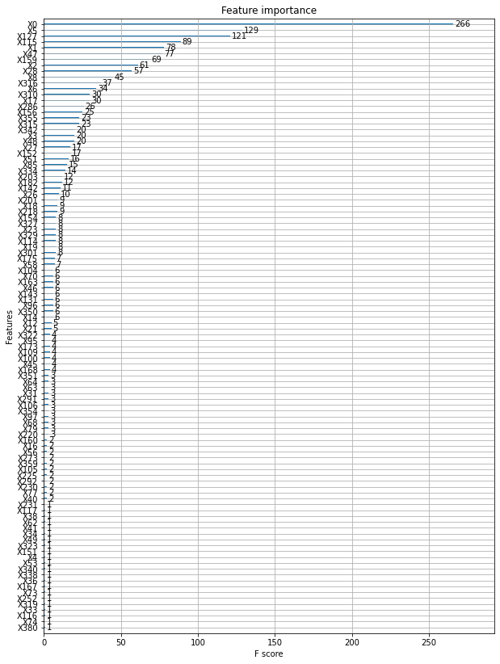

```python
# Visualizing the importance of the independent variables
from xgboost import plot_importance
def plot_features(booster, figsize):
    fig, ax = plt.subplots(1,1,figsize=figsize)
    return plot_importance(booster=booster, ax=ax)
plot_features(xg, (10,14))
```

```python
# Importing "Joblib" library to save the model
from sklearn.externals import joblib
```

```python
# Dumping/Saving the model in a pickle file
joblib.dump(xg, "Project-1.pkl")
```

```
['Project-1.pkl']
```

```python
# Loading the saved model
model = joblib.load("Project-1.pkl")
```

```python
model
```

```
XGBRegressor(alpha=10, base_score=0.5, booster=None, colsample_bylevel=1,
             colsample_bynode=1, colsample_bytree=0.4, gamma=0, gpu_id=-1,
             importance_type='gain', interaction_constraints=None,
             learning_rate=0.02, max_delta_step=0, max_depth=3,
             min_child_weight=1, missing=nan, monotone_constraints=None,
             n_estimators=300, n_jobs=0, num_parallel_tree=1,
             objective='reg:squarederror', random_state=100, reg_alpha=10,
             reg_lambda=1, scale_pos_weight=1, subsample=1, tree_method=None,
             validate_parameters=False, verbosity=None)
```

# PART-B: Predicting for the Test data

```python
# Import the test dataset called "test.csv"
df_test = pd.read_csv("test.csv")
```

```python
df_test.head()
```

|  | ID | X0 | X1 | X2 | X3 | X4 | X5 | X6 | X8 | X10 | ... | X375 | X376 | X377 | X378 | X379 | X380 | X382 | X383 | X384 | X385 |
| --- | --- | --- | --- | --- | --- | --- | --- | --- | --- | --- | --- | --- | --- | --- | --- | --- | --- | --- | --- | --- | --- |
| 0 | 1 | az | v | n | f | d | t | a | w | 0 | ... | 0 | 0 | 0 | 1 | 0 | 0 | 0 | 0 | 0 | 0 |
| 1 | 2 | t | b | ai | a | d | b | g | y | 0 | ... | 0 | 0 | 1 | 0 | 0 | 0 | 0 | 0 | 0 | 0 |
| 2 | 3 | az | v | as | f | d | a | j | j | 0 | ... | 0 | 0 | 0 | 1 | 0 | 0 | 0 | 0 | 0 | 0 |
| 3 | 4 | az | l | n | f | d | z | l | n | 0 | ... | 0 | 0 | 0 | 1 | 0 | 0 | 0 | 0 | 0 | 0 |
| 4 | 5 | w | s | as | c | d | y | i | m | 0 | ... | 1 | 0 | 0 | 0 | 0 | 0 | 0 | 0 | 0 | 0 |

5 rows × 377 columns

```python
# Drop certain variables from the dataset which were dropped from the test data to avoid feature mismatch
df_test = df_test.drop(["ID", "X11", "X93", "X107", "X233", "X235", "X268", "X289", "X290", "X293", "X297", "X330", "X347"],axis=1)
```

```python
df_test.head()
```

|  | X0 | X1 | X2 | X3 | X4 | X5 | X6 | X8 | X10 | X12 | ... | X375 | X376 | X377 | X378 | X379 | X380 | X382 | X383 | X384 | X385 |
| --- | --- | --- | --- | --- | --- | --- | --- | --- | --- | --- | --- | --- | --- | --- | --- | --- | --- | --- | --- | --- | --- |
| 0 | az | v | n | f | d | t | a | w | 0 | 0 | ... | 0 | 0 | 0 | 1 | 0 | 0 | 0 | 0 | 0 | 0 |
| 1 | t | b | ai | a | d | b | g | y | 0 | 0 | ... | 0 | 0 | 1 | 0 | 0 | 0 | 0 | 0 | 0 | 0 |
| 2 | az | v | as | f | d | a | j | j | 0 | 0 | ... | 0 | 0 | 0 | 1 | 0 | 0 | 0 | 0 | 0 | 0 |
| 3 | az | l | n | f | d | z | l | n | 0 | 0 | ... | 0 | 0 | 0 | 1 | 0 | 0 | 0 | 0 | 0 | 0 |
| 4 | w | s | as | c | d | y | i | m | 0 | 0 | ... | 1 | 0 | 0 | 0 | 0 | 0 | 0 | 0 | 0 | 0 |

5 rows × 364 columns

```python
df_test.shape
```

```
(4209, 364)
```

```python
# Checking out the null values in our dataset
df_test.isnull().sum()/len(df)*100
```

```
X0      0.0
X1      0.0
X2      0.0
X3      0.0
X4      0.0
       ...
X380    0.0
X382    0.0
X383    0.0
X384    0.0
X385    0.0
Length: 364, dtype: float64
```

```python
# Checking out the unique values in our dataset
df_test.nunique()
```

```
X0      49
X1      27
X2      45
X3       7
X4       4
        ..
X380     2
X382     2
X383     2
X384     2
X385     2
Length: 364, dtype: int64
```

```python
# Label encoding the alphabetical variables into numerical variables
df_test["X0"] = le.fit_transform(df_test["X0"])
df_test["X1"] = le.fit_transform(df_test["X1"])
df_test["X2"] = le.fit_transform(df_test["X2"])
df_test["X3"] = le.fit_transform(df_test["X3"])
df_test["X4"] = le.fit_transform(df_test["X4"])
df_test["X5"] = le.fit_transform(df_test["X5"])
df_test["X6"] = le.fit_transform(df_test["X6"])
df_test["X8"] = le.fit_transform(df_test["X8"])
```

```python
df_test.head()
```

|  | X0 | X1 | X2 | X3 | X4 | X5 | X6 | X8 | X10 | X12 | ... | X375 | X376 | X377 | X378 | X379 | X380 | X382 | X383 | X384 | X385 |
| --- | --- | --- | --- | --- | --- | --- | --- | --- | --- | --- | --- | --- | --- | --- | --- | --- | --- | --- | --- | --- | --- |
| 0 | 21 | 23 | 34 | 5 | 3 | 26 | 0 | 22 | 0 | 0 | ... | 0 | 0 | 0 | 1 | 0 | 0 | 0 | 0 | 0 | 0 |
| 1 | 42 | 3 | 8 | 0 | 3 | 9 | 6 | 24 | 0 | 0 | ... | 0 | 0 | 1 | 0 | 0 | 0 | 0 | 0 | 0 | 0 |
| 2 | 21 | 23 | 17 | 5 | 3 | 0 | 9 | 9 | 0 | 0 | ... | 0 | 0 | 0 | 1 | 0 | 0 | 0 | 0 | 0 | 0 |
| 3 | 21 | 13 | 34 | 5 | 3 | 31 | 11 | 13 | 0 | 0 | ... | 0 | 0 | 0 | 1 | 0 | 0 | 0 | 0 | 0 | 0 |
| 4 | 45 | 20 | 17 | 2 | 3 | 30 | 8 | 12 | 0 | 0 | ... | 1 | 0 | 0 | 0 | 0 | 0 | 0 | 0 | 0 | 0 |

5 rows × 364 columns

```python
# Scaling the first 7 variables to return their values in the range of (0,1)
df_test["X0"] = mn.fit_transform(df_test[["X0"]])
df_test["X1"] = mn.fit_transform(df_test[["X1"]])
df_test["X2"] = mn.fit_transform(df_test[["X2"]])
df_test["X3"] = mn.fit_transform(df_test[["X3"]])
df_test["X5"] = mn.fit_transform(df_test[["X5"]])
df_test["X6"] = mn.fit_transform(df_test[["X6"]])
df_test["X8"] = mn.fit_transform(df_test[["X8"]])
```

```python
df_test.head()
```

|  | X0 | X1 | X2 | X3 | X4 | X5 | X6 | X8 | X10 | X12 | ... | X375 | X376 | X377 | X378 | X379 | X380 | X382 | X383 | X384 | X385 |
| --- | --- | --- | --- | --- | --- | --- | --- | --- | --- | --- | --- | --- | --- | --- | --- | --- | --- | --- | --- | --- | --- |
| 0 | 0.4375 | 0.884615 | 0.772727 | 0.833333 | 3 | 0.838710 | 0.000000 | 0.916667 | 0 | 0 | ... | 0 | 0 | 0 | 1 | 0 | 0 | 0 | 0 | 0 | 0 |
| 1 | 0.8750 | 0.115385 | 0.181818 | 0.000000 | 3 | 0.290323 | 0.545455 | 1.000000 | 0 | 0 | ... | 0 | 0 | 1 | 0 | 0 | 0 | 0 | 0 | 0 | 0 |
| 2 | 0.4375 | 0.884615 | 0.386364 | 0.833333 | 3 | 0.000000 | 0.818182 | 0.375000 | 0 | 0 | ... | 0 | 0 | 0 | 1 | 0 | 0 | 0 | 0 | 0 | 0 |
| 3 | 0.4375 | 0.500000 | 0.772727 | 0.833333 | 3 | 1.000000 | 1.000000 | 0.541667 | 0 | 0 | ... | 0 | 0 | 0 | 1 | 0 | 0 | 0 | 0 | 0 | 0 |
| 4 | 0.9375 | 0.769231 | 0.386364 | 0.333333 | 3 | 0.967742 | 0.727273 | 0.500000 | 0 | 0 | ... | 1 | 0 | 0 | 0 | 0 | 0 | 0 | 0 | 0 | 0 |

5 rows × 364 columns

```python
# Adding a null variable "y" to the dataset so that it becomes easy to drop the correlated variables
df_test["y"] = 0
```

```python
# Dropping the correlated variables to avoid multi-collinearity issue
df_test = df_test.drop(Cols_to_drop, axis= 1)
```

```python
# Using the saved model "model" to predict for the test data
results = model.predict(df_test)
```

```python
# Adding a column called "y" with predictions to the "test.csv" DataFrame
df_test["y"] = results
```

```python
df_test.head()
```

|  | X0 | X1 | X2 | X3 | X4 | X5 | X6 | X8 | X10 | X12 | ... | X351 | X353 | X354 | X355 | X359 | X369 | X372 | X380 | X383 | y |
| --- | --- | --- | --- | --- | --- | --- | --- | --- | --- | --- | --- | --- | --- | --- | --- | --- | --- | --- | --- | --- | --- |
| 0 | 0.4375 | 0.884615 | 0.772727 | 0.833333 | 3 | 0.838710 | 0.000000 | 0.916667 | 0 | 0 | ... | 0 | 0 | 0 | 0 | 0 | 0 | 0 | 0 | 0 | 78.489677 |
| 1 | 0.8750 | 0.115385 | 0.181818 | 0.000000 | 3 | 0.290323 | 0.545455 | 1.000000 | 0 | 0 | ... | 0 | 0 | 0 | 0 | 0 | 0 | 0 | 0 | 0 | 93.952637 |
| 2 | 0.4375 | 0.884615 | 0.386364 | 0.833333 | 3 | 0.000000 | 0.818182 | 0.375000 | 0 | 0 | ... | 0 | 0 | 0 | 0 | 0 | 0 | 0 | 0 | 0 | 81.053818 |
| 3 | 0.4375 | 0.500000 | 0.772727 | 0.833333 | 3 | 1.000000 | 1.000000 | 0.541667 | 0 | 0 | ... | 0 | 0 | 0 | 0 | 0 | 0 | 0 | 0 | 0 | 79.040871 |
| 4 | 0.9375 | 0.769231 | 0.386364 | 0.333333 | 3 | 0.967742 | 0.727273 | 0.500000 | 0 | 0 | ... | 1 | 0 | 0 | 0 | 0 | 0 | 0 | 0 | 0 | 109.703568 |

5 rows × 179 columns

```python
# Saving the output DataFrame to a CSV file in local directory

df_test.to_csv("D:\\Project_1_Predictions", index= None)
```

### Final accuracy of the model: 65.92%

The model accuracy can be improved by having more amount of data, which means you are giving more information to the machine learning algorithm to understand the various situations and correlate the same before giving the right answer. And having more training data means, we need to add a variety of data that can cover wide-ranging scenarios to avoid biased decisions. Hence, the more data we feed in the model, it will improve the accuracy of the model.